# lab_3_Kovalenko

### Лабораторна робота №3

**Мета** *освоети роботи зї змінними та операцї вводу и виводу*

### **Приклад**

Написати програму, яка вводить довжины катерив `a` та `b` прямокутника та обчислуе його гіпотенузу `c`.

```python
import math

a = float(input("Уведіть значення a:  "))
b = float(input("Уведіть значення b:  "))

# Калькулятор гіпотенузи c
c = math.sqrt(a**2 + b**2)

# Виведення результату
print("с =", c)

# Перевірка результату
if math.isclose(c, 5.0):
    print("Обчислена гіпотенуза збігається з відомим значенням  c = 5.0 ")
else:
    print("Обчислена гіпотенуза не збігається з відомим значенням  c = 5.0 ")
```

### Завдання №1

Написати програму, яка обчислює значення функції Гауса:

```python
import math

def gauss(x, mu=32, sigma=18):
    return (1 / (sigma * math.sqrt(2 * math.pi))) * math.exp(- ((x - mu) ** 2) / (2 * sigma ** 2))

# print(gauss(1))

# print(gauss(1, mu=32, sigma=18))

x = int(input("Уведіть x: "))

print(f"x= {x}: {gauss (1, mu=32, sigma=18 )}")
```

### Завдання №2

Якось Джон (John) мав три яблука, Мері (Mary) мала п’ять яблук, а Адам (Adam) мав шість яблук. Усі вони були дуже щасливі та жили довго. Кінець історії Завдання

- створіть змінні: `john`, `mary`, і `adam`;
- надайте значення змінним. Значення повинні дорівнювати кількості фруктів, якими володіють Джон, Мері, і Адам відповідно;
- зберігши числа в змінних, виведіть змінні в один рядок і розділіть їх комами;
- тепер створіть нову змінну з ім'ям `totalApple`, що дорівнює сумі трьох попередніх змінних;
- вивести значення, збережене в `totalapples`, в консоль;
- надрукувати рядок та ціле число разом в одному рядку, наприклад, "Загальна кількість яблук:" та `total_apples`|.

```python
john = 3
mary = 5
adam = 6

print(f"John: {john}, Mary: {mary}, Adam: {adam}")

totalApples = john + mary + adam

print(f"Загальна кількість яблук {totalApples}")
```

John: 3, Mary: 5, Adam: 6

Загальна кількість яблук 14

### Завдання №3

Милі та кілометри – це одиниці довжини або відстані.

Враховуючи, що 1 миля дорівнює приблизно 1.61 кілометрам, напишіть програму, щоб вона перетворила:

милі у кілометри;

кілометри на милі.

Не змінюйте нічого в існуючому коді. Напишіть свій код у місцях, вказаних ###. Протестуйте вашу програму з даними, які надано у вихідному коді.

```python
kilometers = 12.25
miles = 7.38

# miles to kilometers
miles_to_kilometers = miles * 1.61

# kilometers to miles
kilometers_to_miles = kilometers / 1.61

print(miles, "miles is", round(miles_to_kilometers, 2), "kilometers")
print(kilometers, "kilometers is", round(kilometers_to_miles, 2), "miles")
```

7.38 miles is 11.88 kilometers

12.25 kilometers is 7.61 miles

### Завдання №4

Подивіться код у редакторі: він читає “плаваюче” значення, поміщає його у змінну з ім’ям x, і друкує значення змінної з ім’ям y. Ваше завдання - завершити код, щоб оцінити такий вираз:

```python
x = 0
x = float(x)
y = 3 * x**3 - 2 * x**2 + 3**x - 1
print("y =", y)

x = 1
x = float(x)
y = 3 * x**3 - 2 * x**2 + 3**x - 1
print("y =", y)

x = -1
x = float(x)
y = 3 * x**3 - 2 * x**2 + 3**x - 1
print("y =", y)
```

y = 0.0 y = 3.0 y = -5.666666666666667

### Завдання №5

Код редактора містить коментарі. Спробуйте покращити його: додайте або видаліть коментарі там, де ви вважаєте це доречним (так, іноді видалення коментаря може зробити код більш читабельним) і змініть імена змінних там, де, на вашу думку, це покращить розуміння коду.

```python
# this program calculates seconds from hours

a = 2
seconds = 3600
print("Hours: ", a)
# printing the number of seconds in a given number of hours

# this program ends after calculating seconds in 3 hours.
```

### Завдання №6

Ваше завдання – завершити код, щоб отримати результати чотирьох основних арифметичних операцій.

```python
# input a float value for variable a here
a = 13
# input a float value for variable b here
b = 89
# output the result of addition here
print("Addition", a+b)
# output the result of subtraction here
print("Subtraction", a-b)
# output the result of multiplication here
print("Multiplication", a*b)
# output the result of division here
print("Division", a/b)

print("\nThat's all, folks!")
```

Addition 102 Subtraction -76 Multiplication 1157 Division 0.14606741573033707 That's all, folks!

### Завдання №7

Ваше завдання – завершити код, щоб оцінити такий вираз:

```python
x = float(input("Enter value for x: "))

a = x + (1 / x)
b = x + (1 / a)
c = x + (1 / b)
y = x + (1 / c)
print("y =", y)
```

```python
x = 1
x= float(x)
a = x + (1 / x)
b = x + (1 / a)
c = x + (1 / b)
y = (1 / c)
print("y =", y)

x = 10
x= float(x)
a = x + (1 / x)
b = x + (1 / a)
c = x + (1 / b)
y = (1 / c)
print("y =", y)


x = 100
x= float(x)
a = x + (1 / x)
b = x + (1 / a)
c = x + (1 / b)
y = (1 / c)
print("y =", y)


x = -5
x= float(x)
a = x + (1 / x)
b = x + (1 / a)
c = x + (1 / b)
y = (1 / c)
print("y =", y)
```

y = 0.6000000000000001

y = 0.09901951266867294

y = 0.009999000199950014

y = -0.19258202567760344

### Завдання №8

Ваше завдання - підготувати простий код, здатний порахувати час закінчення періоду часу, вираженого в кількості хвилин (воно може бути як завгодно великим). Час початку вказується у вигляді пари годин (0..23) та хвилин (0..59). Результат повинен бути надрукований на консолі.

Наприклад, якщо подія починається о 12:17 і триває 59 хвилин, вона закінчується о 13:16.

```python
# hour = int(input("Starting time (hours): "))
start_hours = 12
# mins = int(input("Starting time (minutes): "))
start_minutes = 17
# dura = int(input("Event duration (minutes): "))
duration_minutes = 59

end_hours = (start_hours + (start_minutes + duration_minutes) // 60) % 24
end_minutes = (start_minutes + duration_minutes) % 60

print(f"Закінчення годин {end_hours:02}:{end_minutes:02}")
```

Закінчення годин 13:16

### Контрольні запитання

1.Який вивод наступного фрагмента? image.png

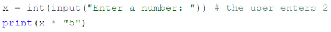

Enter a number: >? 89

55555555555555555555555555555555555555555555555555555555555555555555555555555555555555555

2. Який очікуваний результат наступного фрагмента?

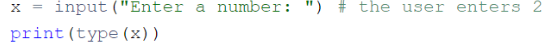

```python
Enter a number: >? 56

<class 'str'>
```